# Working with data: Introducing and comparing data.table and dplyr

Ellen Webborn and Jonno Bourne

bseeR user group, 29th October 2020

# Getting started

[figure not shown]

```r
install.packages("data.table")
library(data.table)
```

[figure not shown]

```r
install.packages("tidyverse") # or "dplyr"
library(tidyverse)
```

# Basic concept

- Data tables are a special kind of data frame
- The general ethos is for conscise code
- Known to be fast and memory-efficient, particularly for csv files and filtering

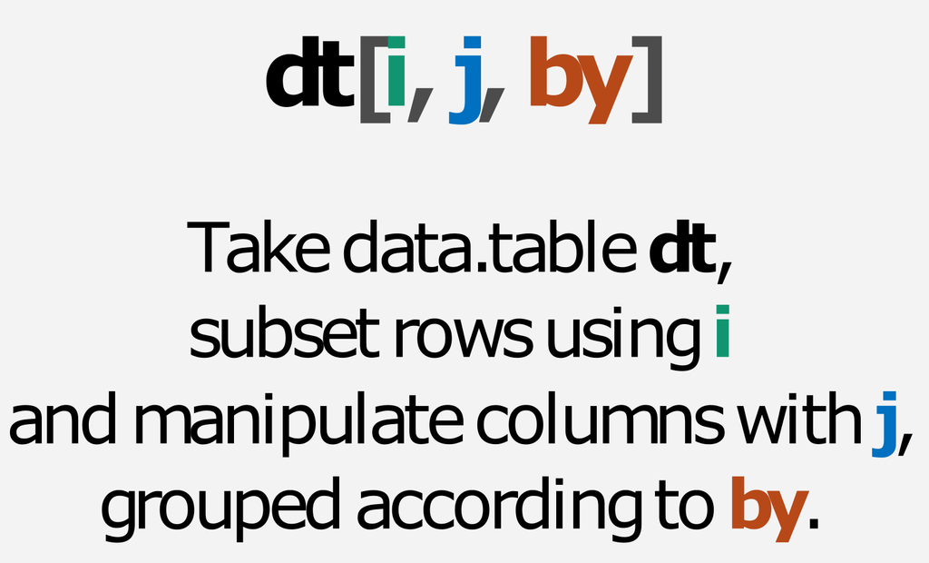

- Tibbles are a special kind of data frame (anything you can do with a data frame you can do with a data table)
- The general ethos is for code that is easy to understand
- Memory efficient for summarising, if not so fast

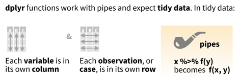

# Creating a simple data.table/tibble:

```r
DT <- data.table(A = 1:5,
                 B = c("Red", "Blue", "Red", "Blue", "Blue"),
                 C = c(TRUE, TRUE, TRUE, TRUE, FALSE))

DT
```

```
##    A    B     C
## 1: 1  Red  TRUE
## 2: 2 Blue  TRUE
## 3: 3  Red  TRUE
## 4: 4 Blue  TRUE
## 5: 5 Blue FALSE
```

```r
df <- tibble(A = 1:5,
                 B = c("Red", "Blue", "Red", "Blue", "Blue"),
                 C = c(TRUE, TRUE, TRUE, TRUE, FALSE))

df
```

```
## # A tibble: 5 x 3
##       A B     C
##   <int> <chr> <lgl>
## 1     1 Red   TRUE
## 2     2 Blue  TRUE
## 3     3 Red   TRUE
## 4     4 Blue  TRUE
## 5     5 Blue  FALSE
```

# Selecting an element in a table

```r
DT[1, 2] # outputs a (single element) data table
```

```
##      B
## 1: Red
```

```r
DT[1, "B"] # equivalent - outputs a data table
```

```
##      B
## 1: Red
```

```r
DT[1, .(B)] # - outputs a data table
```

```
##      B
## 1: Red
```

```r
DT[1, B] # - outputs a vector
```

```
## [1] "Red"
```

```r
df[1, 2] # outputs a tibble
```

```
## # A tibble: 1 x 1
##   B
##   <chr>
## 1 Red
```

```r
df[1, "B"] # equivalent - outputs a tibble
```

```
## # A tibble: 1 x 1
##   B
##   <chr>
## 1 Red
```

```r
df[1, ] %>% select(B) # - outputs a tibble
```

```
## # A tibble: 1 x 1
##   B
##   <chr>
## 1 Red
```

```r
df[1, "B"] %>% pull # - outputs a vector
```

```
## [1] "Red"
```

# Selecting multiple elements in a table

```r
DT[1:3, c("B", "C")]
```

```
##       B    C
## 1:  Red TRUE
## 2: Blue TRUE
## 3:  Red TRUE
```

```r
DT[1:3, .(B, C)]
```

```
##       B    C
## 1:  Red TRUE
## 2: Blue TRUE
## 3:  Red TRUE
```

```r
df[1:3, c("B", "C")]
```

```
## # A tibble: 3 x 2
##   B     C
##   <chr> <lgl>
## 1 Red   TRUE
## 2 Blue  TRUE
## 3 Red   TRUE
```

```r
df %>% select(B, C) %>% slice(1:3)
```

```
## # A tibble: 3 x 2
##   B     C
##   <chr> <lgl>
## 1 Red   TRUE
## 2 Blue  TRUE
## 3 Red   TRUE
```

# Making basic changes

## Add a column

```r
DT[, D := rep(-1, 5)]
DT
```

```
##    A    B     C  D
## 1: 1  Red  TRUE -1
## 2: 2 Blue  TRUE -1
## 3: 3  Red  TRUE -1
## 4: 4 Blue  TRUE -1
## 5: 5 Blue FALSE -1
```

```r
df <- df %>% mutate(D = rep(-1, 5))
df
```

```
## # A tibble: 5 x 4
##       A B     C         D
##   <int> <chr> <lgl> <dbl>
## 1     1 Red   TRUE     -1
## 2     2 Blue  TRUE     -1
## 3     3 Red   TRUE     -1
## 4     4 Blue  TRUE     -1
## 5     5 Blue  FALSE    -1
```

## Change a value according to a rule

```r
DT[B == "Red", D := 99]
DT
```

```
##    A    B     C  D
## 1: 1  Red  TRUE 99
## 2: 2 Blue  TRUE -1
## 3: 3  Red  TRUE 99
## 4: 4 Blue  TRUE -1
## 5: 5 Blue FALSE -1
```

```r
df <- df %>% mutate(D = ifelse(B=="Red", 99, D ))
df
```

```
## # A tibble: 5 x 4
##       A B     C         D
##   <int> <chr> <lgl> <dbl>
## 1     1 Red   TRUE     99
## 2     2 Blue  TRUE     -1
## 3     3 Red   TRUE     99
## 4     4 Blue  TRUE     -1
## 5     5 Blue  FALSE    -1
```

## Rename columns

```r
setnames(DT,
         old = c("A", "C"),
         new = c("A1", "C1"))
# The 'old =' and 'new =' are optional but helpful
DT
```

```
##    A1    B    C1  D
## 1:  1  Red  TRUE 99
## 2:  2 Blue  TRUE -1
## 3:  3  Red  TRUE 99
## 4:  4 Blue  TRUE -1
## 5:  5 Blue FALSE -1
```

```r
df <- df %>% rename(A1 = A,
                    C1 = C)
df
```

```
## # A tibble: 5 x 4
##      A1 B     C1        D
##   <int> <chr> <lgl> <dbl>
## 1     1 Red   TRUE     99
## 2     2 Blue  TRUE     -1
## 3     3 Red   TRUE     99
## 4     4 Blue  TRUE     -1
## 5     5 Blue  FALSE    -1
```

## Delete a column

```r
DT[, C1 := NULL]
DT
```

```
##    A1    B  D
## 1:  1  Red 99
## 2:  2 Blue -1
## 3:  3  Red 99
## 4:  4 Blue -1
## 5:  5 Blue -1
```

```r
df %>% select(-C1)
```

```
## # A tibble: 5 x 3
##      A1 B         D
##   <int> <chr> <dbl>
## 1     1 Red      99
## 2     2 Blue     -1
## 3     3 Red      99
## 4     4 Blue     -1
## 5     5 Blue     -1
```

# Common operators

## Column sum

```r
DT[, sum(D)]
```

```
## [1] 195
```

```r
sum(df$D)
```

```
## [1] 195
```

## Multiple column operations (with multiple outputs)

```r
DT[, .(sum(D), mean(D))]
```

```
##     V1 V2
## 1: 195 39
```

```r
df %>%
  summarise(across(.cols = D, .fns = c(sum, mean)))
```

```
## # A tibble: 1 x 2
##     D_1   D_2
##   <dbl> <dbl>
## 1   195    39
```

## Multiple column operations (naming the outputs in a table)

```r
DT[, .(sumOfD = sum(D),
       meanOfD = mean(D))]
```

```
##    sumOfD meanOfD
## 1:    195      39
```

```r
df %>% summarise(sum = sum(D),
                 mean = mean(D))
```

```
## # A tibble: 1 x 2
##     sum  mean
##   <dbl> <dbl>
## 1   195    39
```

## Add a new column based on other columns

```r
DT[, E := D - A1]
DT[A1 > 2, F := 0]
DT
```

```
##    A1    B  D  E  F
## 1:  1  Red 99 98 NA
## 2:  2 Blue -1 -3 NA
## 3:  3  Red 99 96  0
## 4:  4 Blue -1 -5  0
## 5:  5 Blue -1 -6  0
```

```r
df <- df %>% mutate(E = D-A1,
                    F = ifelse(A1>2, 0, F))
df
```

```
## # A tibble: 5 x 6
##      A1 B     C1        D     E     F
##   <int> <chr> <lgl> <dbl> <dbl> <dbl>
## 1     1 Red   TRUE     99    98     0
## 2     2 Blue  TRUE     -1    -3     0
## 3     3 Red   TRUE     99    96     0
## 4     4 Blue  TRUE     -1    -5     0
## 5     5 Blue  FALSE    -1    -6     0
```

## Get the number of rows

```r
DT[, .N] # number of rows
```

```
## [1] 5
```

```r
DT[B == "Blue", .N] # number of rows with B = Blue
```

```
## [1] 3
```

```r
nrow(df)
```

```
## [1] 5
```

```r
df %>% summarise(B = sum(B=="Blue"))
```

```
## # A tibble: 1 x 1
##       B
##   <int>
## 1     3
```

# Group by

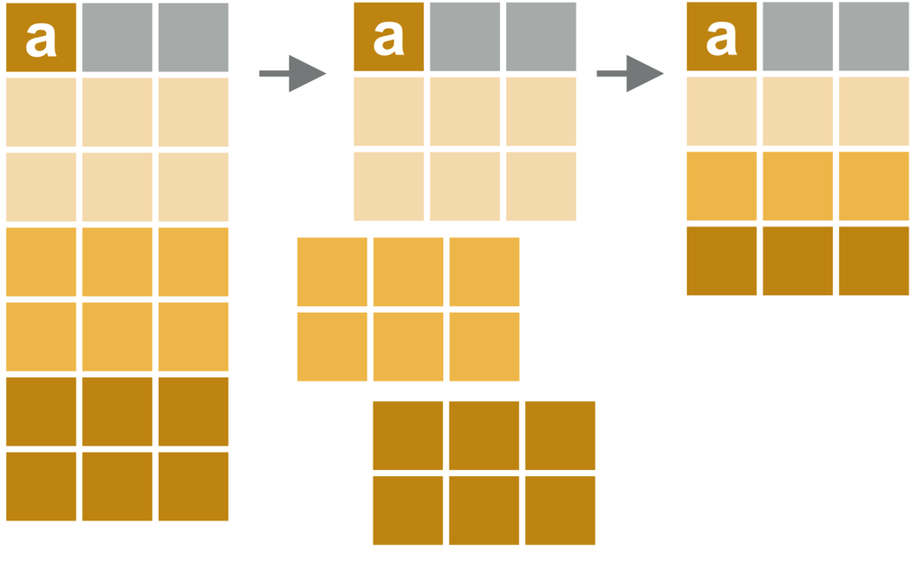

```r
DT[, .N, by = B]
```

```
##       B N
## 1:  Red 2
## 2: Blue 3
```

```r
df %>% group_by(B) %>% summarise(counts = n())
```

```
## # A tibble: 2 x 2
##   B     counts
##   <chr>  <int>
## 1 Blue       3
## 2 Red        2
```

```r
DT[, .N, by = .(B, F)]
```

```
##       B  F N
## 1:  Red NA 1
## 2: Blue NA 1
## 3:  Red  0 1
## 4: Blue  0 2
```

```r
df %>% group_by(B, F) %>% summarise(counts = n())
```

```
## # A tibble: 2 x 3
## # Groups:   B [2]
##   B         F counts
##   <chr> <dbl>  <int>
## 1 Blue      0      3
## 2 Red       0      2
```

# Key by

Orders the rows and creates a key for joins. *order()* just orders the rows

```r
DT[, .N, keyby = .(B, F)]
```

```
##       B  F N
## 1: Blue NA 1
## 2: Blue  0 2
## 3:  Red NA 1
## 4:  Red  0 1
```

The dplyr equivalent is just to arrange the rows

```r
df <- df %>% arrange(B, F)
```

# Reading from and writing to csv files

- data.table is very fast at writing and reading data
- functions **fwrite()** and **fread()** (creates a data table automatically)

```r
fread("my/file/path/data_name.csv")
fwrite(DT, file = "my/file/path/data_name.csv")
```

- the dplyr package doesn’t have its own reading and writing functions
- the readr package can be used which is much faster than the base r functions

```r
# base r functions
read.csv("my/file/path/data_name.csv")
write.csv("my/file/path/data_name.csv")

library(readr)
#readr version much faster than base r
read_csv("my/file/path/data_name.csv")
write_csv("my/file/path/data_name.csv")
```

# Combine multiple data tables

## After reading them in

```r
DT2 <- rbindlist(list(DT, DT[1:3]))
DT2
```

```
##    A1    B  D  E  F
## 1:  1  Red 99 98 NA
## 2:  2 Blue -1 -3 NA
## 3:  3  Red 99 96  0
## 4:  4 Blue -1 -5  0
## 5:  5 Blue -1 -6  0
## 6:  1  Red 99 98 NA
## 7:  2 Blue -1 -3 NA
## 8:  3  Red 99 96  0
```

```r
df2 <- list(df, df[1:3,]) %>% bind_rows()
df2
```

```
## # A tibble: 8 x 6
##      A1 B     C1        D     E     F
##   <int> <chr> <lgl> <dbl> <dbl> <dbl>
## 1     2 Blue  TRUE     -1    -3     0
## 2     4 Blue  TRUE     -1    -5     0
## 3     5 Blue  FALSE    -1    -6     0
## 4     1 Red   TRUE     99    98     0
## 5     3 Red   TRUE     99    96     0
## 6     2 Blue  TRUE     -1    -3     0
## 7     4 Blue  TRUE     -1    -5     0
## 8     5 Blue  FALSE    -1    -6     0
```

## In one step (reading and combining)

```r
rbindlist(lapply(c("DT.csv", "DT.csv"), fread))
```

```r
df1 <- c("DT.csv", "DT.csv") %>%
  purrr::map_df(read_csv) # a core tidyverse package
```

# Basic speed comparison

## Setup

```r
if(user == "EW") {
  setwd("C:/Users/Ellen Webborn/OneDrive - University College London/Documents/R/bseeR user group/dataTableDplyrTalk")
}

# Create a large data table
n <- 10^8
t <- proc.time()
fakeData <- data.table(a = 1:n,
                       b = rnorm(n))
proc.time() - t # elapsed: 9 s

# Write to an RData file
t <- proc.time()
fwrite(fakeData,
       paste(directory, "/fakeDataTable.csv", sep = ""))
proc.time() - t # elapsed: 16 s

# Read from an RData file
t <- proc.time()
fread(paste(directory, "/fakeDataTable.csv", sep = ""))
proc.time() - t # elapsed 39 s
```

```r
# Create a large tibble
n <- 10^8
t <- proc.time()
fakeData2 <- tibble(a = 1:n,
                       b = rnorm(n))
proc.time() - t # elapsed: 9 s

# Write to an RData file
t <- proc.time()
write_csv(fakeData2,
       file = paste(directory, "/fakeTibble.csv", sep = ""))
proc.time() - t # elapsed: 75 s

# Read from an RData file
t <- proc.time()
read_csv(paste(directory, "/fakeTibble.csv", sep = ""))
proc.time() - t # elapsed: 66 s
```

## Results

Time in seconds for each task (table with 10^8 rows and 2 columns)

| package | createTable | writeCSV | readCSV |
| --- | --- | --- | --- |
| data.table | 9 | 16 | 39 |
| dplyr | 9 | 75 | 66 |

# Joins

Joins are a powerful way to combine information from multiple data tables/frames. Consider the following example, where two tables have (at least) one column in common, although not necessarily the same row elements.

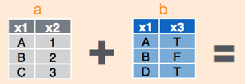

To define what to join ‘on’ data.table defines the ‘key’ of the tables:

```r
setkey(a, x1)
setkey(b, x1)
```

Use ‘setkey**v**()’ to define multiple keys

dplyr specifies the key within each call to a join function.

## Left join

```r
b[a]
```

```r
left_join(a, b, by = "x1")
```

## Right join

```r
a[b]
```

```r
right_join(a, b, by = "x1")
```

## Inner join

```r
a[b, nomatch = 0]
```

```r
inner_join(a, b, by = "x1")
```

# Column names as variables

The **get** and **eval** functions can be used to treat column names as variables. Consder the following example. We want to replace high outliers in each numeric column with NA (this isn’t a scientifically robust plan but it’s helpful to illustrate here).

```r
# install.packages("remotes")
# remotes::install_github("allisonhorst/palmerpenguins")
library(palmerpenguins)

penguins_dt <- as.data.table(penguins) # only needed for data table as penguins is a data frame

cols_for_analysis <- c("bill_length_mm",
                       "bill_depth_mm",
                       "flipper_length_mm",
                       "body_mass_g")

head(penguins_dt)
```

```
##    species    island bill_length_mm bill_depth_mm flipper_length_mm body_mass_g
## 1:  Adelie Torgersen           39.1          18.7               181        3750
## 2:  Adelie Torgersen           39.5          17.4               186        3800
## 3:  Adelie Torgersen           40.3          18.0               195        3250
## 4:  Adelie Torgersen             NA            NA                NA          NA
## 5:  Adelie Torgersen           36.7          19.3               193        3450
## 6:  Adelie Torgersen           39.3          20.6               190        3650
##       sex year
## 1:   male 2007
## 2: female 2007
## 3: female 2007
## 4:   <NA> 2007
## 5: female 2007
## 6:   male 2007
```

```r
for(i in cols_for_analysis) {
  penguins_dt[get(i) > mean(get(i), na.rm = TRUE),
              eval(i) := NA]
}
```

```r
test2 <- penguins %>%
  mutate(across(.cols = all_of(cols_for_analysis),
                .fns = ~ifelse(.x > mean(.x, na.rm = TRUE), NA, .x)
                )
         )

#The `all_of` function makes it explicit when you are using data from outside the data frame. This prevents issues occuring when a column in the data frame has the same name as a vector somewhere else in the workspace
```

```r
head(penguins_dt)
```

```
##    species    island bill_length_mm bill_depth_mm flipper_length_mm body_mass_g
## 1:  Adelie Torgersen           39.1            NA               181        3750
## 2:  Adelie Torgersen           39.5            NA               186        3800
## 3:  Adelie Torgersen           40.3            NA               195        3250
## 4:  Adelie Torgersen             NA            NA                NA          NA
## 5:  Adelie Torgersen           36.7            NA               193        3450
## 6:  Adelie Torgersen           39.3            NA               190        3650
##       sex year
## 1:   male 2007
## 2: female 2007
## 3: female 2007
## 4:   <NA> 2007
## 5: female 2007
## 6:   male 2007
```

# Figures

ggplot2 is part of the tidyverse and data.table is not - but this isn’t a problem for integrating the two.

Consider the following example which uses the penguins dataset

```r
p1 <- ggplot(penguins_dt[!is.na(year),
                         .N,
                         keyby = .(island, year)],
             aes(x = island,
                 y = N,
                 fill = as.factor(year))) +
  geom_bar(stat = "identity",
           position = position_dodge()) +
  labs(x = "Island",
       y = "Number of penguins by sex",
       fill = "Year")
```

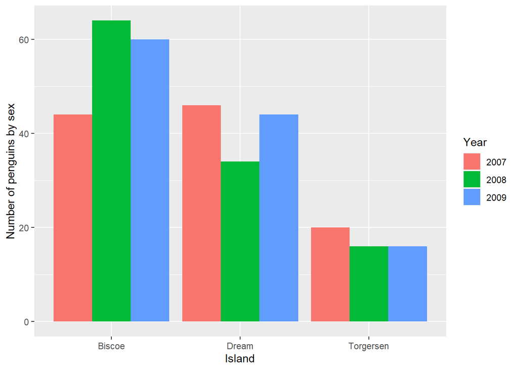

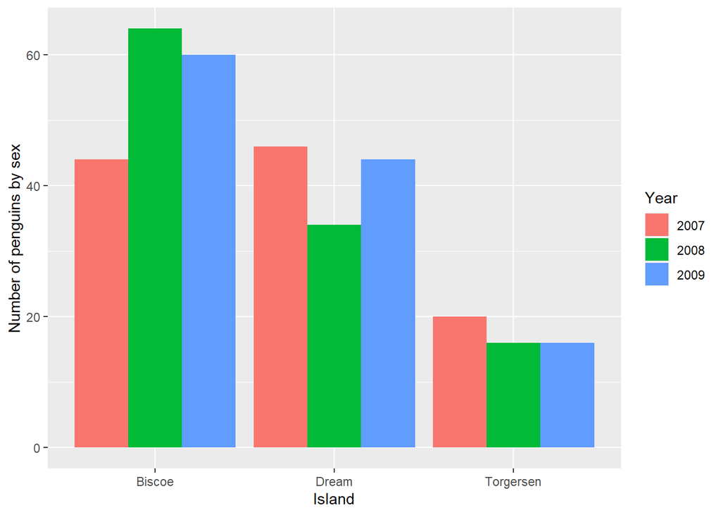

```r
p2 <- penguins %>%
  group_by(island, year) %>%
  summarise(N = n()) %>%
  ggplot(aes(x = island,
             y = N,
             fill = factor(year))) +
  geom_col(position = "dodge") +
  labs(x = "Island",
       y = "Number of penguins by sex",
       fill = "Year")
```

# Resources

- [data.table wiki](https://github.com/Rdatatable/data.table/wiki/Getting-started)
- [dplyr within the tidyverse documentation](https://dplyr.tidyverse.org/)
- [Steph Locke (data) table wrangling](http://stephlocke.info/Rtraining/tablewrangling.html)
- [A data table and dplyr tour](https://atrebas.github.io/post/2019-03-03-datatable-dplyr/)

# Image credits

Most images were borrowed from the data.table cheat sheet. The joins images came from [this page](https://mikoontz.github.io/data-carpentry-week/lesson_joins.html) on multi-table joins with dplyr.